# exercise-09

Sunishka

3/29/2022

Loading in libraries

```r
library(tidyverse)
library(manipulate)
library(skimr)
library(infer)
library(broom)
```

Using the {tidyverse} read_csv() function, load the “Street_et_al_2017.csv” dataset from this URL as a “tibble” named d Do a quick exploratory data analysis where you generate the five-number summary (median, minimum and maximum and 1st and 3rd quartile values), plus mean and standard deviation, for each quantitative variable

```r
f <- "https://raw.githubusercontent.com/difiore/ada-2022-datasets/main/Street_et_al_2017.csv"
d <- read_csv(f, col_names = TRUE) %>%
  drop_na(ECV, Group_size)
colnames(d)
```

```
##  [1] "Species"             "Taxonomic_group"     "Social_learning"
##  [4] "Research_effort"     "ECV"                 "Group_size"
##  [7] "Gestation"           "Weaning"             "Longevity"
## [10] "Sex_maturity"        "Body_mass"           "Maternal_investment"
## [13] "Repro_lifespan"
```

```r
skim(d)
```

Data summary

| Name | d |
| --- | --- |
| Number of rows | 151 |
| Number of columns | 13 |
| _______________________ |  |
| Column type frequency: |  |
| character | 2 |
| numeric | 11 |
| ________________________ |  |
| Group variables | None |

**Variable type: character**

| skim_variable | n_missing | complete_rate | min | max | empty | n_unique | whitespace |
| --- | --- | --- | --- | --- | --- | --- | --- |
| Species | 0 | 1 | 11 | 28 | 0 | 151 | 0 |
| Taxonomic_group | 0 | 1 | 10 | 12 | 0 | 3 | 0 |

**Variable type: numeric**

| skim_variable | n_missing | complete_rate | mean | sd | p0 | p25 | p50 | p75 | p100 | hist |
| --- | --- | --- | --- | --- | --- | --- | --- | --- | --- | --- |
| Social_learning | 8 | 0.95 | 3.18 | 19.62 | 0.00 | 0.00 | 0.00 | 0.00 | 214.00 | ▇▁▁▁▁ |
| Research_effort | 11 | 0.93 | 46.62 | 91.04 | 1.00 | 8.00 | 18.00 | 43.50 | 755.00 | ▇▁▁▁▁ |
| ECV | 0 | 1.00 | 63.36 | 69.35 | 1.63 | 11.46 | 57.86 | 86.56 | 490.41 | ▇▁▁▁▁ |
| Group_size | 0 | 1.00 | 13.40 | 14.04 | 1.00 | 3.20 | 8.35 | 18.65 | 85.00 | ▇▂▁▁▁ |
| Gestation | 35 | 0.77 | 161.87 | 36.61 | 59.99 | 136.41 | 165.02 | 180.66 | 259.42 | ▁▅▇▃▂ |
| Weaning | 53 | 0.65 | 308.72 | 259.24 | 40.00 | 122.40 | 221.74 | 364.74 | 1260.81 | ▇▃▁▁▁ |
| Longevity | 45 | 0.70 | 322.20 | 131.35 | 103.00 | 216.00 | 300.00 | 395.10 | 720.00 | ▆▇▅▂▁ |
| Sex_maturity | 56 | 0.63 | 1434.81 | 941.46 | 283.18 | 672.10 | 1399.88 | 1894.11 | 5465.72 | ▇▆▂▁▁ |
| Body_mass | 0 | 1.00 | 6575.55 | 12263.57 | 43.00 | 800.00 | 4450.00 | 7492.50 | 120950.00 | ▇▁▁▁▁ |
| Maternal_investment | 58 | 0.62 | 466.72 | 291.57 | 99.99 | 255.66 | 386.47 | 543.96 | 1492.30 | ▇▅▂▁▁ |
| Repro_lifespan | 64 | 0.58 | 8724.20 | 3475.01 | 2512.16 | 6067.07 | 8161.66 | 10716.60 | 18581.38 | ▅▇▅▂▁ |

From this dataset, plot brain size (ECV) as a function of social group size (Group_size), longevity (Longevity), juvenile period length (Weaning), and reproductive lifespan (Repro_lifespan)

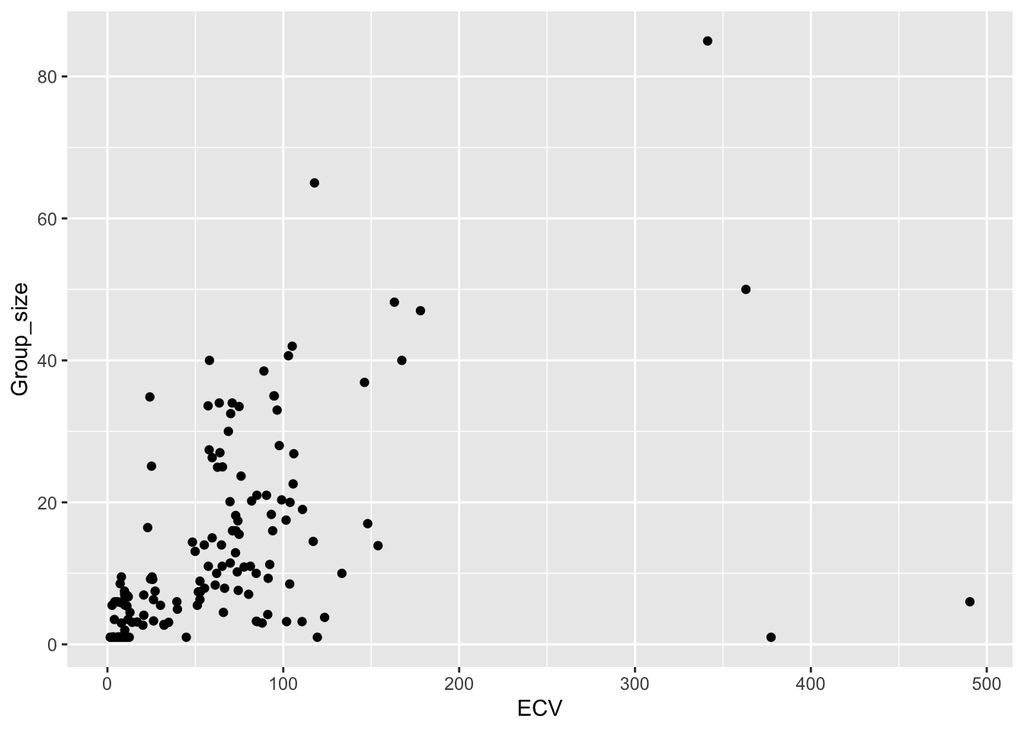

```r
ggplot(data=d, aes(x=ECV, y=Group_size)) +
  geom_point()
```

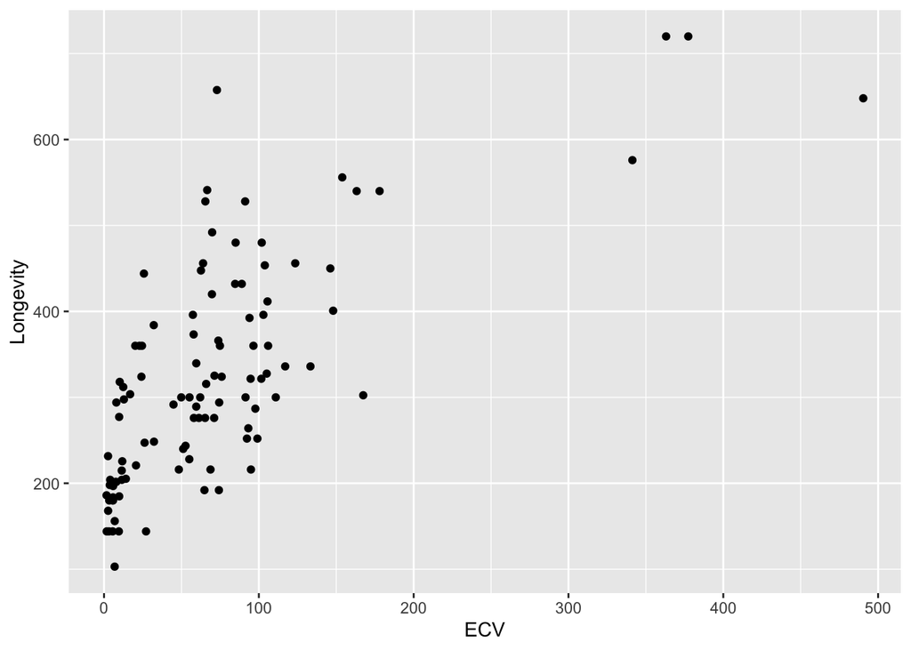

```r
ggplot(data=d, aes(x=ECV, y=Longevity)) +
  geom_point()
```

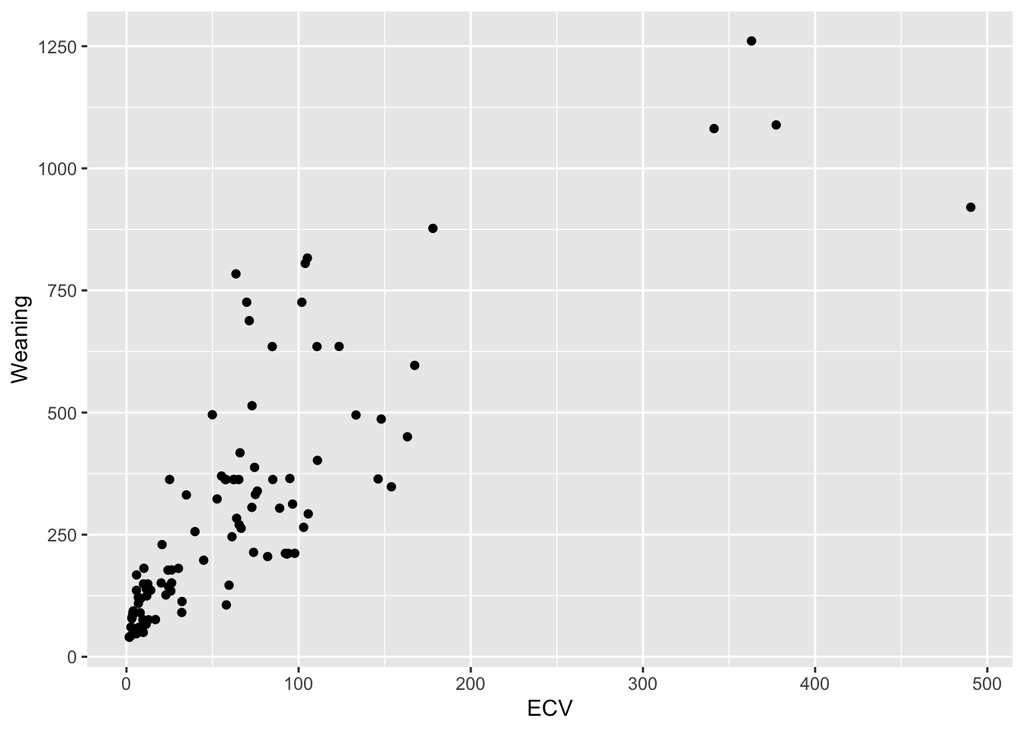

```r
ggplot(data=d, aes(x=ECV, y=Weaning)) +
  geom_point()
```

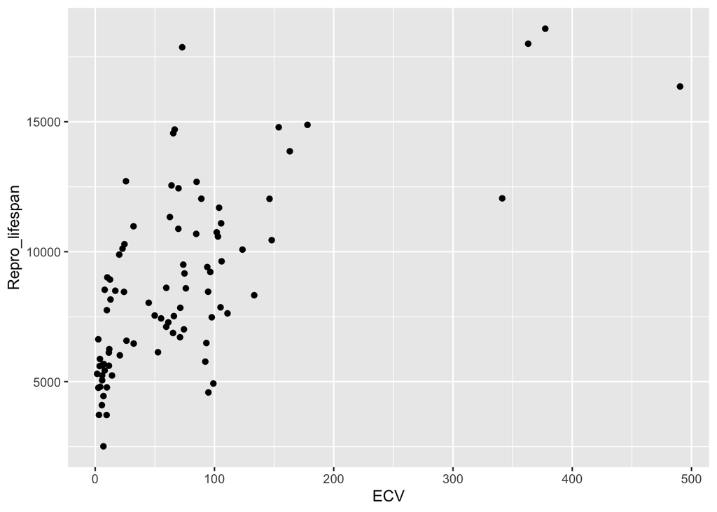

```r
ggplot(data=d, aes(x=ECV, y=Repro_lifespan)) +
  geom_point()
```

Derive by hand the ordinary least squares regression coefficients β1 and β0 for ECV as a function of social group size

```r
beta1 = cor(d$ECV, d$Group_size) * (sd(d$ECV) / sd(d$Group_size))
beta0 = mean(d$ECV) - beta1 * mean(d$Group_size)

#beta1 is 2.46 and beta0 is 30.35
```

Confirm that you get the same results using the lm() function

```r
m = lm(ECV ~ Group_size, data=d)
broom::tidy(m)
```

```
## # A tibble: 2 × 5
##   term        estimate std.error statistic  p.value
##   <chr>          <dbl>     <dbl>     <dbl>    <dbl>
## 1 (Intercept)    30.4      6.80       4.47 1.56e- 5
## 2 Group_size      2.46     0.351      7.02 7.26e-11
```

Yes, the regression coefficients using lm() match what I had above.

Repeat the analysis above for three different major radiations of primates – “catarrhines,” “platyrrhines,” and “strepsirhines”) separately. These are stored in the variable Taxonomic_group.

(I summarise these in the next code block)

```r
d_catarrhines = d %>%
  filter(Taxonomic_group == "Catarrhini")
beta1_catarrhines = cor(d_catarrhines$ECV, d_catarrhines$Group_size) * (sd(d_catarrhines$ECV) / sd(d_catarrhines$Group_size))
beta0_catarrhines = mean(d_catarrhines$ECV) - beta1 * mean(d_catarrhines$Group_size)
m_catarrhines = lm(ECV ~ Group_size, data=d_catarrhines)
broom::tidy(m_catarrhines)
```

```
## # A tibble: 2 × 5
##   term        estimate std.error statistic     p.value
##   <chr>          <dbl>     <dbl>     <dbl>       <dbl>
## 1 (Intercept)    83.4     14.9        5.59 0.000000438
## 2 Group_size      1.15     0.579      1.98 0.0518
```

```r
d_platyrrhines = d %>%
  filter(Taxonomic_group == "Platyrrhini")
beta1_platyrrhines = cor(d_platyrrhines$ECV, d_platyrrhines$Group_size) * (sd(d_platyrrhines$ECV) / sd(d_platyrrhines$Group_size))
beta0_platyrrhines = mean(d_platyrrhines$ECV) - beta1 * mean(d_platyrrhines$Group_size)
m_platyrrhines = lm(ECV ~ Group_size, data=d_platyrrhines)
broom::tidy(m_platyrrhines)
```

```
## # A tibble: 2 × 5
##   term        estimate std.error statistic  p.value
##   <chr>          <dbl>     <dbl>     <dbl>    <dbl>
## 1 (Intercept)    16.2      7.39       2.19 0.0356
## 2 Group_size      1.97     0.455      4.32 0.000136
```

```r
d_strepsirhines = d %>%
  filter(Taxonomic_group == "Strepsirhini")
beta1_strepsirhines = cor(d_strepsirhines$ECV, d_strepsirhines$Group_size) * (sd(d_strepsirhines$ECV) / sd(d_strepsirhines$Group_size))
beta0_strepsirhines = mean(d_strepsirhines$ECV) - beta1 * mean(d_strepsirhines$Group_size)
m_strepsirhines = lm(ECV ~ Group_size, data=d_strepsirhines)
broom::tidy(m_strepsirhines)
```

```
## # A tibble: 2 × 5
##   term        estimate std.error statistic  p.value
##   <chr>          <dbl>     <dbl>     <dbl>    <dbl>
## 1 (Intercept)     8.18     2.14       3.83 0.000404
## 2 Group_size      1.84     0.473      3.89 0.000332
```

Do your regression coefficients differ among groups? How might you determine this?

Yes, these regression coefficients are different as seen using both by hand beta0 and beta1 calculations and the lm() function seen above.

```r
col_1 = c("catarrhines", "platyrrhines", "strepsirhines")
col_2 = c(beta0_catarrhines, beta0_platyrrhines, beta0_strepsirhines)
col_3 = c(beta1_catarrhines,beta1_platyrrhines, beta1_strepsirhines)

(data.frame(taxonomic_group = col_1,
            intercept = col_2,
            slope = col_3))
```

```
##   taxonomic_group intercept    slope
## 1     catarrhines 56.485545 1.146322
## 2    platyrrhines  9.828067 1.965176
## 3   strepsirhines  6.214449 1.840664
```

For your first regression of ECV on social group size, calculate the standard error for the slope coefficient, the 95% CI, and the p value associated with this coefficient by hand. Also extract this same information from the results of running the lm() function.

```r
#by hand
residuals = d$ECV - (beta0 + beta1*d$Group_size)
num = sum(residuals^2)/(length(residuals)-2)
den = sum((d$Group_size - mean(d$Group_size))^2)
se_beta1 = sqrt(num/den)

lower_beta1 = beta1 - qt(0.975, df = nrow(d)-2) * se_beta1
upper_beta1 = beta1 + qt(0.975, df = nrow(d)-2) * se_beta1

t_stat_beta1 = beta1/se_beta1
p_beta1 = 2 * pt(t_stat_beta1, df = nrow(d)-2, lower.tail = FALSE)

col1 = c("beta1", "standard error of slope coefficient", "lower_CI", "upper_CI", "p value")
col2 = c(beta1, se_beta1, lower_beta1, upper_beta1, p_beta1)

(data.frame(names = col1, value = col2))
```

```
##                                 names        value
## 1                               beta1 2.463071e+00
## 2 standard error of slope coefficient 3.508061e-01
## 3                            lower_CI 1.769874e+00
## 4                            upper_CI 3.156269e+00
## 5                             p value 7.259435e-11
```

```r
#using lm()
original_slope = lm(ECV ~ Group_size, data=d) %>%
  tidy(conf.int = TRUE, conf.level = 0.95) %>%
  filter(term == "Group_size")
```

Then, use a permutation approach with 1000 permutations to generate a null sampling distribution for the slope coefficient. What is it that you need to permute? What is the p value associated with your original slope coefficient?

I need to permute the response variable, ECV.

```r
permuted_slope = d %>%
  specify(ECV ~ Group_size) %>%
  hypothesize(null = "independence") %>%
  generate(reps = 1000, type = "permute") %>%
  calculate(stat = "slope")

get_confidence_interval(permuted_slope, level = 0.95)
```

```
## # A tibble: 1 × 2
##   lower_ci upper_ci
##      <dbl>    <dbl>
## 1   -0.715    0.874
```

```r
p_value = permuted_slope %>%
  mutate(abs_stat = abs(stat)) %>%
  summarise(estimate = mean(abs_stat >= abs(pull(original_slope, estimate))))

(p_value)
```

```
## # A tibble: 1 × 1
##   estimate
##      <dbl>
## 1        0
```

Use bootstrapping to generate a 95% CI for your estimate of the slope coefficient using both the percentile method and the theory-based method (i.e., based on the standard deviation of the bootstrapped sampling distribution). Do these CIs suggest that your slope coefficient is different from zero?

```r
boot_slope = d %>%
  specify(ECV ~ Group_size) %>%
  generate(reps = 1000, type = "bootstrap") %>%
  calculate(stat = "slope")

#calculating CIs based on quantile
ci_boot_slope_1 = get_ci(boot_slope, level = 0.95, type = "percentile")
#calculating CIs based on SE
ci_boot_slope_2 = get_ci(boot_slope, level = 0.95, type = "se",
       point_estimate = pull(boot_slope, mean(stat)))
```